# Preparación de los Datos

Adolfo De Unánue T.

01/12/2014

```r
# Cargamos el dataset

ds.path <- "/Users/andreuboada/Dropbox/ESTADISTICA/itam-dm/alumnos/andreuboada/Tarea3/pruebacup98lrn.txt" # Puede ser un URL o una dirección en el directorio

ds.name <- "pruebacup98lrn" # Nombre de nuestro conjunto de datos, e.g. algas, german

ds <- loadData(name=ds.name, full_path=ds.path, sep=",", head=TRUE)
```

```
## Buscando el RDS en  /Users/andreuboada/Dropbox/ESTADISTICA/itam-dm/alumnos/andreuboada/Tarea3/rds/pruebacup98lrn.rds
## 3.108 0.118 3.246 0 0
```

```r
ds <- tbl_df(ds) # Para obtener un print mejorado
```

# 1 Introducción

Explicamos la procedencia del archivo, como lo obtuvimos, indicar si es una muestra, etc.

Si es una muestra indicar el método de muestreo y el algoritmo para generar los números aleatorios

## 1.1 Variables

Explicación de las variables que componen (o que deberían de componer) el dataset

# 2 Estructura General

```r
ds
```

```
## Source: local data frame [95,412 x 481]
##
##    ODATEDW OSOURCE TCODE STATE    ZIP MAILCODE PVASTATE  DOB NOEXCH
## 1     8901     GRI     0    IL  61081                   3712      0
## 2     9401     BOA     1    CA  91326                   5202      0
## 3     9001     AMH     1    NC  27017                      0      0
## 4     8701     BRY     0    CA  95953                   2801      0
## 5     8601             0    FL  33176                   2001      0
## 6     9401     CWR     0    AL  35603                      0      0
## 7     8701     DRK     0    IN  46755                   6001      0
## 8     9401     NWN     0    LA  70611                      0      0
## 9     8801     LIS     1    IA  51033                      0      0
## 10    9401     MSD     1    TN 37127-                   3211      0
## ..     ...     ...   ...   ...    ...      ...      ...  ...    ...
## Variables not shown: RECINHSE (fctr), RECP3 (fctr), RECPGVG (fctr),
##   RECSWEEP (fctr), MDMAUD (fctr), DOMAIN (fctr), CLUSTER (int), AGE (int),
##   AGEFLAG (fctr), HOMEOWNR (fctr), CHILD03 (fctr), CHILD07 (fctr), CHILD12
##   (fctr), CHILD18 (fctr), NUMCHLD (int), INCOME (int), GENDER (fctr),
##   WEALTH1 (int), HIT (int), MBCRAFT (int), MBGARDEN (int), MBBOOKS (int),
##   MBCOLECT (int), MAGFAML (int), MAGFEM (int), MAGMALE (int), PUBGARDN
##   (int), PUBCULIN (int), PUBHLTH (int), PUBDOITY (int), PUBNEWFN (int),
##   PUBPHOTO (int), PUBOPP (int), DATASRCE (int), MALEMILI (int), MALEVET
##   (int), VIETVETS (int), WWIIVETS (int), LOCALGOV (int), STATEGOV (int),
##   FEDGOV (int), SOLP3 (int), SOLIH (int), MAJOR (fctr), WEALTH2 (int),
##   GEOCODE (int), COLLECT1 (fctr), VETERANS (fctr), BIBLE (fctr), CATLG
##   (fctr), HOMEE (fctr), PETS (fctr), CDPLAY (fctr), STEREO (fctr),
##   PCOWNERS (fctr), PHOTO (fctr), CRAFTS (fctr), FISHER (fctr), GARDENIN
##   (fctr), BOATS (fctr), WALKER (fctr), KIDSTUFF (fctr), CARDS (fctr),
##   PLATES (fctr), LIFESRC (int), PEPSTRFL (fctr), POP901 (int), POP902
##   (int), POP903 (int), POP90C1 (int), POP90C2 (int), POP90C3 (int),
##   POP90C4 (int), POP90C5 (int), ETH1 (int), ETH2 (int), ETH3 (int), ETH4
##   (int), ETH5 (int), ETH6 (int), ETH7 (int), ETH8 (int), ETH9 (int), ETH10
##   (int), ETH11 (int), ETH12 (int), ETH13 (int), ETH14 (int), ETH15 (int),
##   ETH16 (int), AGE901 (int), AGE902 (int), AGE903 (int), AGE904 (int),
##   AGE905 (int), AGE906 (int), AGE907 (int), CHIL1 (int), CHIL2 (int),
##   CHIL3 (int), AGEC1 (int), AGEC2 (int), AGEC3 (int), AGEC4 (int), AGEC5
##   (int), AGEC6 (int), AGEC7 (int), CHILC1 (int), CHILC2 (int), CHILC3
##   (int), CHILC4 (int), CHILC5 (int), HHAGE1 (int), HHAGE2 (int), HHAGE3
##   (int), HHN1 (int), HHN2 (int), HHN3 (int), HHN4 (int), HHN5 (int), HHN6
##   (int), MARR1 (int), MARR2 (int), MARR3 (int), MARR4 (int), HHP1 (int),
```

[output cut: 50 more lines]

```
##   RDATE_7 (int), RDATE_8 (int), RDATE_9 (int), RDATE_10 (int), RDATE_11
##   (int), RDATE_12 (int), RDATE_13 (int), RDATE_14 (int), RDATE_15 (int),
##   RDATE_16 (int), RDATE_17 (int), RDATE_18 (int), RDATE_19 (int), RDATE_20
##   (int), RDATE_21 (int), RDATE_22 (int), RDATE_23 (int), RDATE_24 (int),
##   RAMNT_3 (dbl), RAMNT_4 (dbl), RAMNT_5 (int), RAMNT_6 (dbl), RAMNT_7
##   (dbl), RAMNT_8 (dbl), RAMNT_9 (dbl), RAMNT_10 (dbl), RAMNT_11 (dbl),
##   RAMNT_12 (dbl), RAMNT_13 (dbl), RAMNT_14 (dbl), RAMNT_15 (dbl), RAMNT_16
##   (dbl), RAMNT_17 (dbl), RAMNT_18 (dbl), RAMNT_19 (dbl), RAMNT_20 (dbl),
##   RAMNT_21 (dbl), RAMNT_22 (dbl), RAMNT_23 (dbl), RAMNT_24 (dbl), RAMNTALL
##   (dbl), NGIFTALL (int), CARDGIFT (int), MINRAMNT (dbl), MINRDATE (int),
##   MAXRAMNT (dbl), MAXRDATE (int), LASTGIFT (dbl), LASTDATE (int), FISTDATE
##   (int), NEXTDATE (int), TIMELAG (int), AVGGIFT (dbl), CONTROLN (int),
##   TARGET_B (int), TARGET_D (dbl), HPHONE_D (int), RFA_2R (fctr), RFA_2F
##   (int), RFA_2A (fctr), MDMAUD_R (fctr), MDMAUD_F (fctr), MDMAUD_A (fctr),
##   CLUSTER2 (int), GEOCODE2 (fctr)
```

## 2.1 Tamaño

```r
dim(ds)
```

```
## [1] 95412   481
```

## 2.2 Estructura

```r
sapply(ds, class)
```

```
##   ODATEDW   OSOURCE     TCODE     STATE       ZIP  MAILCODE  PVASTATE
## "integer"  "factor" "integer"  "factor"  "factor"  "factor"  "factor"
##       DOB    NOEXCH  RECINHSE     RECP3   RECPGVG  RECSWEEP    MDMAUD
## "integer"  "factor"  "factor"  "factor"  "factor"  "factor"  "factor"
##    DOMAIN   CLUSTER       AGE   AGEFLAG  HOMEOWNR   CHILD03   CHILD07
##  "factor" "integer" "integer"  "factor"  "factor"  "factor"  "factor"
##   CHILD12   CHILD18   NUMCHLD    INCOME    GENDER   WEALTH1       HIT
##  "factor"  "factor" "integer" "integer"  "factor" "integer" "integer"
##   MBCRAFT  MBGARDEN   MBBOOKS  MBCOLECT   MAGFAML    MAGFEM   MAGMALE
## "integer" "integer" "integer" "integer" "integer" "integer" "integer"
##  PUBGARDN  PUBCULIN   PUBHLTH  PUBDOITY  PUBNEWFN  PUBPHOTO    PUBOPP
## "integer" "integer" "integer" "integer" "integer" "integer" "integer"
##  DATASRCE  MALEMILI   MALEVET  VIETVETS  WWIIVETS  LOCALGOV  STATEGOV
## "integer" "integer" "integer" "integer" "integer" "integer" "integer"
##    FEDGOV     SOLP3     SOLIH     MAJOR   WEALTH2   GEOCODE  COLLECT1
## "integer" "integer" "integer"  "factor" "integer" "integer"  "factor"
##  VETERANS     BIBLE     CATLG     HOMEE      PETS    CDPLAY    STEREO
##  "factor"  "factor"  "factor"  "factor"  "factor"  "factor"  "factor"
##  PCOWNERS     PHOTO    CRAFTS    FISHER  GARDENIN     BOATS    WALKER
##  "factor"  "factor"  "factor"  "factor"  "factor"  "factor"  "factor"
##  KIDSTUFF     CARDS    PLATES   LIFESRC  PEPSTRFL    POP901    POP902
##  "factor"  "factor"  "factor" "integer"  "factor" "integer" "integer"
##    POP903   POP90C1   POP90C2   POP90C3   POP90C4   POP90C5      ETH1
## "integer" "integer" "integer" "integer" "integer" "integer" "integer"
##      ETH2      ETH3      ETH4      ETH5      ETH6      ETH7      ETH8
## "integer" "integer" "integer" "integer" "integer" "integer" "integer"
##      ETH9     ETH10     ETH11     ETH12     ETH13     ETH14     ETH15
## "integer" "integer" "integer" "integer" "integer" "integer" "integer"
##     ETH16    AGE901    AGE902    AGE903    AGE904    AGE905    AGE906
## "integer" "integer" "integer" "integer" "integer" "integer" "integer"
##    AGE907     CHIL1     CHIL2     CHIL3     AGEC1     AGEC2     AGEC3
## "integer" "integer" "integer" "integer" "integer" "integer" "integer"
##     AGEC4     AGEC5     AGEC6     AGEC7    CHILC1    CHILC2    CHILC3
## "integer" "integer" "integer" "integer" "integer" "integer" "integer"
##    CHILC4    CHILC5    HHAGE1    HHAGE2    HHAGE3      HHN1      HHN2
## "integer" "integer" "integer" "integer" "integer" "integer" "integer"
##      HHN3      HHN4      HHN5      HHN6     MARR1     MARR2     MARR3
## "integer" "integer" "integer" "integer" "integer" "integer" "integer"
##     MARR4      HHP1      HHP2       DW1       DW2       DW3       DW4
## "integer" "integer" "integer" "integer" "integer" "integer" "integer"
```

[output cut: 83 more lines]

```
## "integer" "integer" "integer" "integer" "integer" "integer" "integer"
##   RAMNT_3   RAMNT_4   RAMNT_5   RAMNT_6   RAMNT_7   RAMNT_8   RAMNT_9
## "numeric" "numeric" "integer" "numeric" "numeric" "numeric" "numeric"
##  RAMNT_10  RAMNT_11  RAMNT_12  RAMNT_13  RAMNT_14  RAMNT_15  RAMNT_16
## "numeric" "numeric" "numeric" "numeric" "numeric" "numeric" "numeric"
##  RAMNT_17  RAMNT_18  RAMNT_19  RAMNT_20  RAMNT_21  RAMNT_22  RAMNT_23
## "numeric" "numeric" "numeric" "numeric" "numeric" "numeric" "numeric"
##  RAMNT_24  RAMNTALL  NGIFTALL  CARDGIFT  MINRAMNT  MINRDATE  MAXRAMNT
## "numeric" "numeric" "integer" "integer" "numeric" "integer" "numeric"
##  MAXRDATE  LASTGIFT  LASTDATE  FISTDATE  NEXTDATE   TIMELAG   AVGGIFT
## "integer" "numeric" "integer" "integer" "integer" "integer" "numeric"
##  CONTROLN  TARGET_B  TARGET_D  HPHONE_D    RFA_2R    RFA_2F    RFA_2A
## "integer" "integer" "numeric" "integer"  "factor" "integer"  "factor"
##  MDMAUD_R  MDMAUD_F  MDMAUD_A  CLUSTER2  GEOCODE2
##  "factor"  "factor"  "factor" "integer"  "factor"
```

*NOTA: Indicar si hay una discrepancia entre las clases de las variables en el data set y en su significado, i.e. fechas que no son fechas, si no factores, etc.*

# 3 Sumario Estadístico

## 3.1 Variables demográficas

## 3.2 Número de veces que el donador respondió a otras campañas

## 3.3 Overlay data (?)

## 3.4 Intereses del donador

## 3.5 Estatus PEP star RFA

## 3.6 Características de la vecindad del donador

## 3.7 Histórico de promociones

## 3.8 Resúmen de variables del histórico de promociones

## 3.9 Histórico de donativos

## 3.10 Resúmen de variables del histórico de donativos

## 3.11 ID y targets

## 3.12 RFA

**RFA** significa *Recency/Frequency/Donation Amount*

## 3.13 Clúster y Geocode

# 4 Descripción de las variables de salida

```r
(porcentaje.respuesta.b <- round(100 * prop.table(table(ds$TARGET_B)), digits=1))
```

```
##
##    0    1
## 94.9  5.1
```

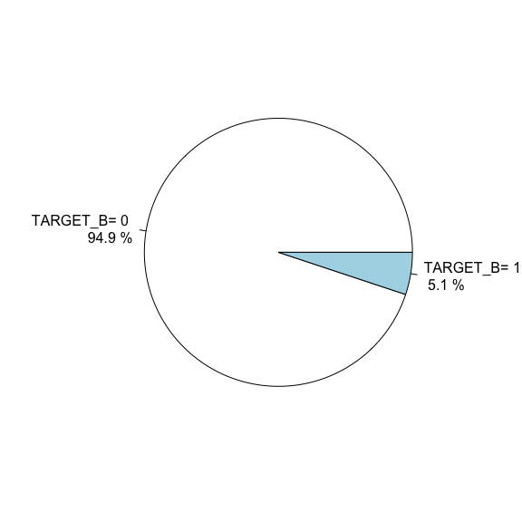

```
##    Min. 1st Qu.  Median    Mean 3rd Qu.    Max.
##    1.00   10.00   13.00   15.62   20.00  200.00
```

Las donaciones positivas son 4843 y están distribuidas así:

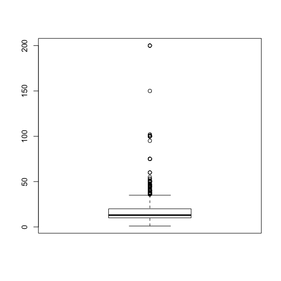

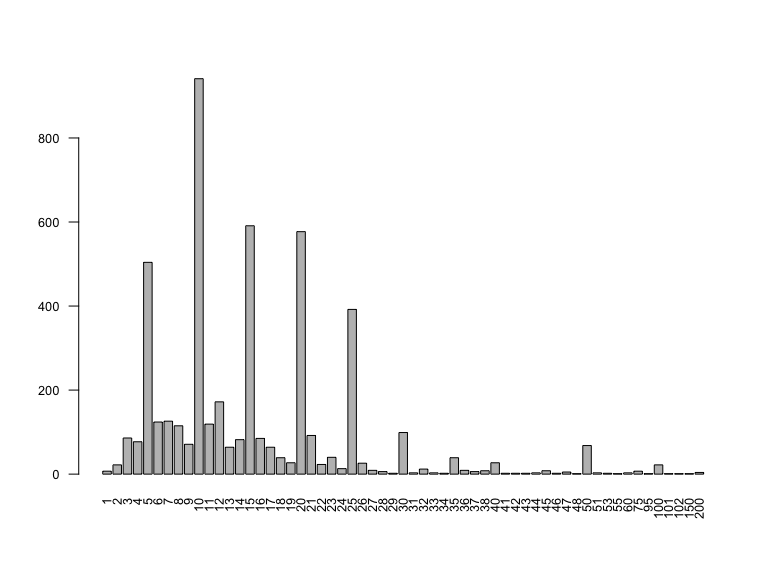

De acuerdo a la gráfica de arriba, discretizamos `TARGET_D` como sigue:

```r
ds$TARGET_D2 <- cut(ds$TARGET_D, right=FALSE, breaks=c(0,0.1, 10,15,20,25,30,50, max(ds$TARGET_D)))
```

```
##
##  [0,0.1) [0.1,10)  [10,15)  [15,20)  [20,25)  [25,30)  [30,50) [50,200)
##    90569     1132     1378      806      745      435      233      110
```

# 5 Limpieza de metadatos

Estandarizamos los nombres de las variables al estándar de `R`, quedando de la siguiente manera:

```
##   [1] "odatedw"   "osource"   "tcode"     "state"     "zip"
##   [6] "mailcode"  "pvastate"  "dob"       "noexch"    "recinhse"
##  [11] "recp3"     "recpgvg"   "recsweep"  "mdmaud"    "domain"
##  [16] "cluster"   "age"       "ageflag"   "homeownr"  "child03"
##  [21] "child07"   "child12"   "child18"   "numchld"   "income"
##  [26] "gender"    "wealth1"   "hit"       "mbcraft"   "mbgarden"
##  [31] "mbbooks"   "mbcolect"  "magfaml"   "magfem"    "magmale"
##  [36] "pubgardn"  "pubculin"  "pubhlth"   "pubdoity"  "pubnewfn"
##  [41] "pubphoto"  "pubopp"    "datasrce"  "malemili"  "malevet"
##  [46] "vietvets"  "wwiivets"  "localgov"  "stategov"  "fedgov"
##  [51] "solp3"     "solih"     "major"     "wealth2"   "geocode"
##  [56] "collect1"  "veterans"  "bible"     "catlg"     "homee"
##  [61] "pets"      "cdplay"    "stereo"    "pcowners"  "photo"
##  [66] "crafts"    "fisher"    "gardenin"  "boats"     "walker"
##  [71] "kidstuff"  "cards"     "plates"    "lifesrc"   "pepstrfl"
```

[output cut: 82 more lines]

# 6 Ajuste de formatos

Las clases de las variables son

```r
sapply(ds, class)
```

[output not shown]

# 7 Transformación de variables

En esta sección incluímos la transformación de las variables necesarias (normalización, estandarización, *binning*, `log`, etc.)

```r
vars <- names(ds) # Guardamos los nombres de variables

target <- c("target.b", "target.d", "target.d2")  # Si el modelo es supervisado
risk <- NULL # Si se proveé, es la importancia de la observación respecto a la variable (es una variable de salida)
costo <- NULL # Costo de equivocarse en la predicción (Si se proveé) (es una variable de salida)
id <- "controln" # Armar una id con columnas, o seleccionar el id del dataset
```

# 8 Recodificación

Antes de pasar a la etapa de ignorar variables, es importante **recodificar**.

- Hay métodos como el `randomForest` que no soporta variables categóricas con más de 32 niveles, habría que agruparlos (e.g. si son países se pueden reagrupar por región, similitud -esto requiere otra base de datos, etc.)
- Si las fechas son `timestamp` hay que extraer variables categóricas como `mes`, `día.de.la.semana`, `fin.de.semana`, `temporada`, etc. claro que depende del tipo del problema al que nos estemos enfrentando.

# 9 Variables a ignorar

Identificamos en una variable `vars.a.ignorar`, las columnas a ignorar en el entrenamiento del modelo.

### 9.0.1 IDs y variables de salida

```r
vars.a.ignorar <- union(union(id, if (exists("risk")) risk), if(exists("cost")) cost)
```

### 9.0.2 Constantes y valores únicos por observación

```r
# Ignoramos las que tengan un único valor por cada observación, pueden ser IDs
# IMPORTANTE: Esto puede eliminar fechas, ver sección anterior

ids <- names(which(sapply(ds, function(x) length(unique(x)) == nrow(ds))))

# Ignoramos los factores que tengan muchos niveles
# IMPORTANTE: ver sección anterior

factors <- which(sapply(ds[vars], is.factor))
niveles <- sapply(factors, function(x) length(levels(ds[[x]])))
(muchos.niveles <- names(which(niveles > 32)))
```

```
##  [1] "osource" "state"   "zip"     "rfa.3"   "rfa.4"   "rfa.5"   "rfa.6"
##  [8] "rfa.7"   "rfa.8"   "rfa.9"   "rfa.10"  "rfa.11"  "rfa.12"  "rfa.13"
## [15] "rfa.14"  "rfa.15"  "rfa.16"  "rfa.17"  "rfa.18"  "rfa.19"  "rfa.20"
## [22] "rfa.21"  "rfa.22"  "rfa.23"  "rfa.24"
```

```r
vars.a.ignorar <- union(vars.a.ignorar, muchos.niveles)

# Constantes
constantes <- names(which(sapply(ds[vars], function(x) all(x == x[1L]))))

vars.a.ignorar <- union(vars.a.ignorar, c(ids, constantes))
```

### 9.0.3 Faltantes

```r
# Las que sean puros NAs
ids.nas.count <- sapply(ds[vars], function(x) sum(is.na(x)))
ids.nas <- names(which(ids.nas.count == nrow(ds)))

vars.a.ignorar <- union(ids.nas, vars.a.ignorar)
```

```r
# Las que tengan muchos NAs (un 70% o más)
ids.many.nas <- names(which(ids.nas.count >= 0.7*nrow(ds)))

vars.a.ignorar <- union(ids.many.nas, vars.a.ignorar)
```

Las variables a ignorar son 75 y son las siguientes:

```
##  [1] "numchld"  "solp3"    "solih"    "geocode"  "rdate.3"  "rdate.4"
##  [7] "rdate.5"  "rdate.6"  "rdate.7"  "rdate.8"  "rdate.9"  "rdate.10"
## [13] "rdate.11" "rdate.12" "rdate.13" "rdate.14" "rdate.15" "rdate.16"
## [19] "rdate.17" "rdate.18" "rdate.19" "rdate.20" "rdate.21" "rdate.22"
## [25] "rdate.23" "rdate.24" "ramnt.3"  "ramnt.4"  "ramnt.5"  "ramnt.6"
## [31] "ramnt.7"  "ramnt.8"  "ramnt.9"  "ramnt.10" "ramnt.11" "ramnt.12"
## [37] "ramnt.13" "ramnt.14" "ramnt.15" "ramnt.16" "ramnt.17" "ramnt.18"
## [43] "ramnt.19" "ramnt.20" "ramnt.21" "ramnt.22" "ramnt.23" "ramnt.24"
## [49] "controln" "osource"  "state"    "zip"      "rfa.3"    "rfa.4"
## [55] "rfa.5"    "rfa.6"    "rfa.7"    "rfa.8"    "rfa.9"    "rfa.10"
## [61] "rfa.11"   "rfa.12"   "rfa.13"   "rfa.14"   "rfa.15"   "rfa.16"
## [67] "rfa.17"   "rfa.18"   "rfa.19"   "rfa.20"   "rfa.21"   "rfa.22"
## [73] "rfa.23"   "rfa.24"   "rfa.2r"
```

### 9.0.4 Variable de salida (`target`)

Si el problema de minado, es supervisado, removemos las observaciones que tengan `NA` en la variable `target`

```r
dim(ds)
```

```
## [1] 95412   482
```

```r
ds <- ds[!is.na(ds[target[1]]),]
ds <- ds[!is.na(ds[target[2]]),]
dim(ds)
```

```
## [1] 95412   482
```

Si el problema es de clasificación, hay que convertir la variable `target` a categórica.

```r
sapply(ds[,target], class)
```

```
##  target.b  target.d target.d2
## "integer" "numeric"  "factor"
```

```r
ds[target[1]] <- as.factor(ds[[target[1]]])
table(ds[target[1]])
```

```
##
##     0     1
## 90569  4843
```

```r
sapply(ds[,target], class)
```

```
##  target.b  target.d target.d2
##  "factor" "numeric"  "factor"
```

Mostramos la distribución (esto nos indicará si el problema no está balanceado)

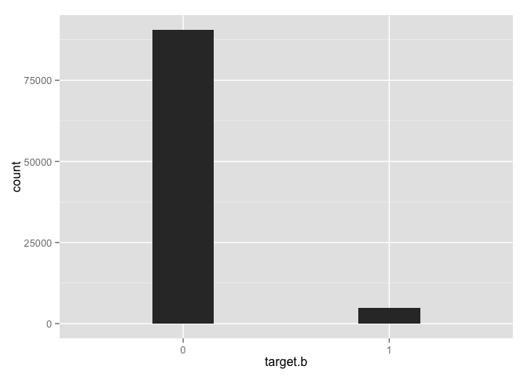

```r
ggplot(data=ds, aes_string(x=target[1])) + geom_bar(width=0.3)
```

# 10 Variables correlacionadas

```r
(system.time(vars.cor <- cor(ds[which(sapply(ds, is.numeric))], use="pairwise.complete.obs")))
```

```
##    user  system elapsed
## 177.816   0.993 179.427
```

```r
vars.cor[upper.tri(vars.cor, diag=TRUE)] <- NA

vars.cor <- vars.cor                                  %>%
            abs()                                     %>%
            data.frame()                              %>%
            mutate(var1=row.names(vars.cor))          %>%
            gather(var2, cor, -var1)                  %>%
            na.omit()


vars.cor <- vars.cor[order(-abs(vars.cor$cor)), ]

if (!file.exists("output")) dir.create("output") # Creamos la carpeta output, si no existe

# Guardar a CSV para tenerlo como respaldo
write.csv(vars.cor, "output/absolute_correlation.csv", row.names=FALSE)

(muy.cor <- filter(vars.cor, cor > 0.95)) # Mostramos las que tengan más del 95% de correlación
```

```
##        var1     var2       cor
## 1   rdate.4    solp3 1.0000000
## 2   ramnt.4    solp3 1.0000000
## 3   rdate.5  lifesrc 1.0000000
## 4  rdate.13  rdate.5 1.0000000
## 5  rdate.15  rdate.5 1.0000000
## 6  rdate.17  rdate.5 1.0000000
## 7  ramnt.13  rdate.5 1.0000000
## 8  ramnt.15  rdate.5 1.0000000
## 9  ramnt.24  rdate.5 1.0000000
## 10  ramnt.5 rdate.13 1.0000000
## 11  ramnt.5 rdate.15 1.0000000
## 12  ramnt.5  ramnt.3 1.0000000
## 13  ramnt.7  ramnt.5 1.0000000
## 14 ramnt.13  ramnt.5 1.0000000
```

[output cut: 57 more lines]

```r
# Habría que decidir si se remueven y cuales se remueven (var1 o var2)
vars.a.ignorar <- union(vars.a.ignorar, muy.cor$var2)
```

Obtenemos la correlación entre las variables y los **target**

Para variables categóricas medimos su **asociación** con una prueba $\chi$-cuadrada

```r
sapply(names(which(sapply(ds.positive, is.factor))), pruebaChiCuadrada, var2=ds$target.d2)
```

[output not shown]

# 11 Valores faltantes

En esta sección hay que poner la estrategia de manejo de valores faltantes elegida durante la etapa del EDA.

Hay muy pocas ocasiones donde es recomendable dejar que el modelo se encargue de las imputaciones.

Las observaciones a omitir, guárdalas en `observaciones.omitidas`.

```r
observaciones.omitidas <- NULL

if (!file.exists("output")) dir.create("output") # Creamos la carpeta clean, si no existe

if(exists("observaciones.omitidas")) {
  write.csv(observaciones.omitidas, "output/observaciones_omitidas.csv", row.names=FALSE)
}
```

# 12 Normalizar niveles

Removemos espacios, puntuaciones, camelCase, etc. en los niveles de los factores supervivientes.

```r
factors <- which(sapply(ds[vars], is.factor))
for (f in factors) levels(ds[[f]]) <- normalizarNombres(levels(ds[[f]]))
```

# 13 Identificación de Variables

## 13.1 Variables independientes

```r
(vars.input <- setdiff(vars, target))
```

```
##   [1] "tcode"    "mailcode" "pvastate" "noexch"   "recinhse" "recp3"
##   [7] "recpgvg"  "recsweep" "mdmaud"   "domain"   "cluster"  "age"
##  [13] "ageflag"  "homeownr" "child03"  "child07"  "child12"  "child18"
##  [19] "income"   "gender"   "wealth1"  "hit"      "mbcraft"  "mbgarden"
##  [25] "mbcolect" "magfaml"  "magfem"   "magmale"  "pubgardn" "pubculin"
##  [31] "pubhlth"  "pubdoity" "pubnewfn" "pubphoto" "pubopp"   "datasrce"
##  [37] "malemili" "malevet"  "vietvets" "wwiivets" "localgov" "stategov"
##  [43] "fedgov"   "major"    "wealth2"  "collect1" "veterans" "bible"
##  [49] "catlg"    "homee"    "pets"     "cdplay"   "stereo"   "pcowners"
##  [55] "photo"    "crafts"   "fisher"   "gardenin" "boats"    "walker"
##  [61] "kidstuff" "cards"    "plates"   "pepstrfl" "pop903"   "pop90c1"
##  [67] "pop90c2"  "pop90c3"  "pop90c4"  "pop90c5"  "eth1"     "eth3"
##  [73] "eth4"     "eth6"     "eth7"     "eth8"     "eth9"     "eth10"
##  [79] "eth11"    "eth12"    "eth13"    "eth14"    "eth15"    "eth16"
##  [85] "age904"   "age906"   "age907"   "chil1"    "chil2"    "chil3"
```

[output cut: 47 more lines]

```r
idxs.input <- sapply(vars.input, function(x) which(x == names(ds)), USE.NAMES=FALSE)
```

## 13.2 Variables numéricas

```r
idxs.numericas <- intersect(idxs.input, which(sapply(ds, is.numeric)))
(vars.numericas <- names(ds)[idxs.numericas])
```

```
##   [1] "tcode"    "cluster"  "age"      "income"   "wealth1"  "hit"
##   [7] "mbcraft"  "mbgarden" "mbcolect" "magfaml"  "magfem"   "magmale"
##  [13] "pubgardn" "pubculin" "pubhlth"  "pubdoity" "pubnewfn" "pubphoto"
##  [19] "pubopp"   "datasrce" "malemili" "malevet"  "vietvets" "wwiivets"
##  [25] "localgov" "stategov" "fedgov"   "wealth2"  "pop903"   "pop90c1"
##  [31] "pop90c2"  "pop90c3"  "pop90c4"  "pop90c5"  "eth1"     "eth3"
##  [37] "eth4"     "eth6"     "eth7"     "eth8"     "eth9"     "eth10"
##  [43] "eth11"    "eth12"    "eth13"    "eth14"    "eth15"    "eth16"
##  [49] "age904"   "age906"   "age907"   "chil1"    "chil2"    "chil3"
##  [55] "agec1"    "agec2"    "agec3"    "agec4"    "agec5"    "agec6"
##  [61] "agec7"    "chilc1"   "chilc2"   "chilc3"   "chilc4"   "chilc5"
##  [67] "hhage2"   "hhage3"   "hhn1"     "hhn2"     "hhn5"     "hhn6"
##  [73] "marr1"    "marr2"    "marr3"    "marr4"    "dw2"      "dw3"
##  [79] "dw7"      "dw8"      "dw9"      "hv2"      "hv3"      "hv4"
##  [85] "hu1"      "hu2"      "hu3"      "hu4"      "hu5"      "hhd1"
```

[output cut: 40 more lines]

## 13.3 Variables categóricas

```r
idxs.categoricas <- intersect(idxs.input, which(sapply(ds, is.factor)))
(vars.categoricas <- names(ds)[idxs.categoricas])
```

```
##  [1] "mailcode" "pvastate" "noexch"   "recinhse" "recp3"    "recpgvg"
##  [7] "recsweep" "mdmaud"   "domain"   "ageflag"  "homeownr" "child03"
## [13] "child07"  "child12"  "child18"  "gender"   "major"    "collect1"
## [19] "veterans" "bible"    "catlg"    "homee"    "pets"     "cdplay"
## [25] "stereo"   "pcowners" "photo"    "crafts"   "fisher"   "gardenin"
## [31] "boats"    "walker"   "kidstuff" "cards"    "plates"   "pepstrfl"
## [37] "rfa.2"    "rfa.2a"   "mdmaud.r" "mdmaud.f" "mdmaud.a" "geocode2"
```

## 13.4 Variables target

```r
target
```

```
## [1] "target.b"  "target.d"  "target.d2"
```

# 14 Tarea

## 14.1 Convertir fecha en categorica: viejo, mediano, nuevo

```r
ds$fecha = as.POSIXlt(ds$odatedw*86400,origin="1970-01-01 00:00.00", tz="GMT")
ds$year = year(ds$fecha)
(cortes <- quantile(ds$fecha, c(0, 0.33,0.66,1)))
```

```
##               0%              33%              66%             100%
## "1992-09-28 GMT" "1994-08-24 GMT" "1995-09-28 GMT" "1996-07-24 GMT"
```

```r
ds$antiguedad <- cut(ds$fecha, breaks = cortes, labels = c('viejo','mediano','nuevo'))
```

## 14.2 Pasar el codigo postal a estado

```r
zipcodes <- read.csv('zip_code_database.csv', header = TRUE, fill=TRUE)
zipcodes$zip <- as.character(zipcodes$zip)


arregla_zip <- function(zip){
  if(nchar(zip)<4){
    return(paste('00',zip,sep=''))
  }else{
    if(nchar(zip)==4){
      return(paste('0',zip,sep=''))
    }else{
      return(zip)
    }
  }
}

ds$zip <- apply(as.data.frame(ds$zip), 1, arregla_zip)
zipcodes <- zipcodes %>% select(zip,primary_city,state,latitude,longitude)
ds <- merge(ds,zipcodes,by='zip')
```

## 14.3 Categoricas a numericas

```r
vars.categoricas
```

```
##  [1] "mailcode" "pvastate" "noexch"   "recinhse" "recp3"    "recpgvg"
##  [7] "recsweep" "mdmaud"   "domain"   "ageflag"  "homeownr" "child03"
## [13] "child07"  "child12"  "child18"  "gender"   "major"    "collect1"
## [19] "veterans" "bible"    "catlg"    "homee"    "pets"     "cdplay"
## [25] "stereo"   "pcowners" "photo"    "crafts"   "fisher"   "gardenin"
## [31] "boats"    "walker"   "kidstuff" "cards"    "plates"   "pepstrfl"
## [37] "rfa.2"    "rfa.2a"   "mdmaud.r" "mdmaud.f" "mdmaud.a" "geocode2"
```

```r
cat_to_numeric <- function(ds,vars.categoricas){
  for(var in vars.categoricas){
    tab <- prop.table(table(ds[,var]))
    noms <- names(tab)
    props <- as.numeric(tab)
    cambia <- function(x){
      ind = which(noms == x)
      return(props[ind])
    }
    ds[,paste(var,'.num',sep='')] <- apply(as.data.frame(ds[,var]),1,cambia)
  }
  return(ds)
}
ds <- cat_to_numeric(ds,vars.categoricas)
```

## 14.4 Quitar variables muy desbalanceadas

```r
muy_desbalanceado <- function(ds, vars.categoricas, max.prop = 0.9){
  vars.a.ignorar <- c()
  for(var in vars.categoricas){
    tab <- prop.table(table(ds[,var]))
    if(max(tab)>max.prop){
      vars.a.ignorar <- c(vars.a.ignorar, var)
    }
  }
  return(vars.a.ignorar)
}

vars.a.ignorar.2 <- muy_desbalanceado(ds,vars.categoricas,0.95)
vars.a.ignorar.2
```

```
##  [1] "mailcode" "pvastate" "noexch"   "recp3"    "recpgvg"  "recsweep"
##  [7] "mdmaud"   "child03"  "child07"  "child12"  "child18"  "major"
## [13] "homee"    "boats"    "kidstuff" "cards"    "plates"   "mdmaud.r"
## [19] "mdmaud.f" "mdmaud.a"
```

# 15 Apéndice: Ambiente